# lab3_prop

#### ΔΗΜΗΤΡΙΟΣ ΖΕΡΚΕΛΙΔΗΣ ~ 03400049

#### ΜΑΡΙΑ ΚΑΙΚΤΖΟΓΛΟΥ ~ 03400052

3η Προπαρασκευαστική

#### STEP 0

```python
# This Python 3 environment comes with many helpful analytics libraries installed
# It is defined by the kaggle/python docker image: https://github.com/kaggle/docker-python
# For example, here's several helpful packages to load in

import numpy as np # linear algebra
import pandas as pd # data processing, CSV file I/O (e.g. pd.read_csv)

# Input data files are available in the "../input/" directory.
# For example, running this (by clicking run or pressing Shift+Enter) will list all files under the input directory

import os
for dirname, _, filenames in os.walk('/kaggle/input'):
    for filename in filenames:
        print(os.path.join(dirname, filename))

# Any results you write to the current directory are saved as output.
```

[output not shown]

[output cut: 10613 more lines]

[output not shown]

```python
import torch
import numpy
device = torch.device("cuda:0" if torch.cuda.is_available() else "cpu")
print(device)
```

```
cuda:0
```

#### STEP 1

Παρακάτω διαλέγουμε 2 διαφορετικά είδη μουσικής, ώστε να επιλέξουμε ένα δείγμα από αυτά τα είδη.

```python
#c=0
with open('/kaggle/input/patreco3-multitask-affective-music/data/fma_genre_spectrograms/train_labels.txt') as f:
    #if c<1:
        #print(f.readlines()[0:])                    #[1:] because we want the 2nd line , 1st line has column names
    lines = np.array([l.rstrip().split('\t') for l in f.readlines()[1:]])
    #c+=1
```

Βλέπουμε πως διαλέξαμε psych-rock και post-rock

```python
#print(lines[0:2])
                                #np.unique(lines[:,1]) shows all the labels we have
label1, label2 = np.random.choice(np.unique(lines[:,1]), 2, replace=False)

print(label1,label2)
```

```
Psych-Rock Post-Rock
```

```python
len(np.unique(lines[:,1])) # number of labels
```

```
20
```

```python
sample1 = lines[lines[:, 1] == label1][0][0]
sample2 = lines[lines[:, 1] == label2][0][0]
print(sample1,sample2)
print(label1,label2)
```

```
108290.fused.full.npy.gz 108077.fused.full.npy.gz
Psych-Rock Post-Rock
```

Φορτώνουμε 2 τυχαία αρχεία σύμφωνα με το label που πήραμε από τα προηγούμενα βήματα.

```python
path = '/kaggle/input/patreco3-multitask-affective-music/data/fma_genre_spectrograms/train/'



filename1 =  path + '.'.join(sample1.split(".")[:-1])
filename2 = path + '.'.join(sample2.split(".")[:-1])

#with gzip.GzipFile(filename1, 'r') as f:
spec1 = np.load(filename1)
spec2 = np.load(filename2)
```

Βλέπουμε πως αποτελούνται απο 140 συχνότητες και τα δύο δείγματα , ενώ στα timesteps διαφέρουν για λίγο.

```python
print(spec1.shape,spec2.shape)  # (frequencies x time steps)
```

```
(140, 1291) (140, 1293)
```

```python
mel1, chroma1 = spec1[:128], spec1[128:]
mel2, chroma2 = spec2[:128], spec2[128:]
```

Τα mel spectrograms έχουν 128 συχνότητες, ενώ τα chromagrams 12.

```python
print(mel1.shape,chroma1.shape)
print(mel2.shape,chroma2.shape)#100857.beatsync.fused.npy
```

```
(128, 1291) (12, 1291)
(128, 1293) (12, 1293)
```

Παρακάτω βλέπουμε τα σπεκτρογράμματα mel.

Ένα σπεκτρόγραμμα , είναι ουσιαστικά όταν σε ένα σήμα εφαρμόζουμε μετασχηματισμό φουριέ και έτσι διαχωρίζει τις ξεχωριστές συχνότητες που υπάρχουν σε αυτό το μείγμα εισόδου που δώσαμε. Επίσης στον άξονα y έχουμε εφαρμόσει μετασχηματισμό λογαρίθμου γιατί ο άνθρωπος ακούει μέχρι ένα συγκεκριμένο όριο συχνοτήτων. Ο άξονας χ είναι ο χρόνος και το χρώμα δείχνει την ένταση σε db.

H κλίμακας mel είναι το αποτέλεσμα κάποιου μη γραμμικού μετασχηματισμού της κλίμακας της συχνότητας(δεν είναι Hz πλέον αλλά κάτι λογαριθμικό). O λόγος που χρησιμοποιείται λόγω της αντιληπτικής απόστασης των συχνοτήτων , καθώς ο άνθρωπος δε μπορεί να ακούσει μεγάλες ποικιλία συχνοτήτων.

Αυτή η κλίμακα Mel είναι κατασκευασμένη έτσι ώστε οι ήχοι ίσης απόστασης μεταξύ τους στην κλίμακα Mel, επίσης "να ακούγονται" στους ανθρώπους καθώς είναι ίσοι σε απόσταση το ένα από το άλλο σε αντίθεση με την κλίμακα Hz.

**mel spectrogram** Είναι ουσιαστικά, ένα σπεκτρόγραμμα όπως είπαμε απλά αυτή τη φορά έχει στον άξονα y τη κλίμακα mel

**πως φτίαχνεται λοιπόν ένα σπεκτρόγραμμα με τη χρήση mel scale** -Separate to windows -πολογίστε το FFT (γρήγορο μετασχηματισμό Fourier) για κάθε παράθυρο που μετασχηματίζεται από το πεδίο χρόνου στο πεδίο συχνότητας. -Δημιούργησε μια κλίμακα mel. -Δημιούργησε ένα spectrogram για κάθε παράθυρο.

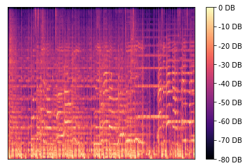

```python
import librosa.display
import matplotlib.pyplot as plt
librosa.display.specshow(mel1)
plt.colorbar(format="%d DB")
```

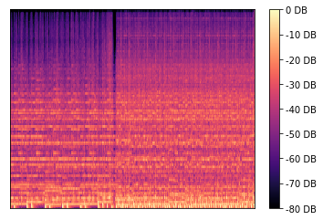

```python
librosa.display.specshow(mel2)
plt.colorbar(format="%d DB")
```

Παρατηρούμε οτι το 1ο σπεκτρόγραμμα έχει μεγαλύτερο amplitude από το 2ο.

#### STEP 2

Παρατηρούμε ότι τα samples δεν έχουν ίδιο αριθμό timesteps οπότε εάν θέλουμε να εκπαιδεύσουμε ένα LSTM με τέτοια δεδομένα θα πρέπει να κάνουμε pad τις ακολουθίες έτσι ώστε να έχουν όλα τα δεδομένα το ίδιο μέγεθος.

Παρ' όλα αυτά το κυριότερο πρόβλημα είναι το μέγεθος των ακολουθιών το οποίο είναι τεράστιο και θα χρειαστεί ένα δίκτυο το οποίο θα αντιμετωπίζει πολλά προβλήματα όπως δυσκολία στην εκπαίδευση, πολλούς πόρους και δε θα γενικέυει.

```python
print(mel1.shape,mel2.shape)

print("timesteps για το 1ο δείγμα: {}".format(mel1.shape[1]))
print("timesteps για το 2ο δείγμα: {}".format(mel2.shape[1]))
print("διαφορά timestep 2 δειγμάτων: {}".format(mel1.shape[1]-mel2.shape[1]))
```

```
(128, 1291) (128, 1293)
timesteps για το 1ο δείγμα: 1291
timesteps για το 2ο δείγμα: 1293
διαφορά timestep 2 δειγμάτων: -2
```

Παρακάτω επαναλαμβάνουμε τα ίδια βήματα αλλά για τα beat synced spectrograms

Παρατηρούμε πως τώρα έχουμε πολύ μικρότερο αριθμό timesteps , γεγονός που κάνει πιο αποδοτική τη χρήση LSTM.

```python
with open('/kaggle/input/patreco3-multitask-affective-music/data/fma_genre_spectrograms/train_labels.txt') as f:
    lines2 = np.array([l.rstrip().split('\t') for l in f.readlines()[1:]])

label1, label2 = np.random.choice(np.unique(lines2[:,1]), 2, replace=False)

sample1 = lines2[lines2[:, 1] == label1][0][0]
sample2 = lines2[lines2[:, 1] == label2][0][0]

path = '/kaggle/input/patreco3-multitask-affective-music/data/fma_genre_spectrograms_beat/train/'

filename1 =  path + '.'.join(sample1.split(".")[:-1])
filename2 = path +  '.'.join(sample2.split(".")[:-1])


#with gzip.GzipFile(filename1, 'r') as f:
spec1 = np.load(filename1)
spec2 = np.load(filename2)
```

```python
mel_beat1, chroma_beat1 = spec1[:128], spec1[128:]
mel_beat2, chroma_beat2 = spec2[:128], spec2[128:]
```

```python
print(mel_beat1.shape,mel_beat2.shape)
```

```
(128, 50) (128, 62)
```

Παρακάτω βλέπουμε τα mel spectrograms των beat_sync αρχείων.

**Σύγκριση των παρακάτω με αυτά του βήματος 1:**

Είναι εμφανές πως πλέον δεν υπάρχει αρκετή πληροφορία ,όπως πριν. Σαν εικόνα αν το κρίνουμε είναι σα να έχουμε κάτι σε χαμηλότερη ανάλυση, το οποίο είναι λογικό γιατί έχουμε μικρότερο αριθμό timesteps και άρα είναι σα να κάναμε μια δειγματοληψία στο αρχείο.

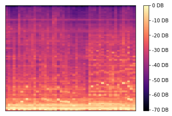

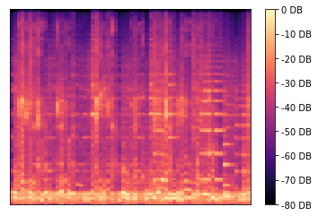

```python
#specshow with mel beat
librosa.display.specshow(mel_beat1)
plt.colorbar(format="%d DB")
plt.show()
librosa.display.specshow(mel_beat2)
plt.colorbar(format="%d DB")
plt.show()
```

STEP 3 ~ CHROMAGRAMS

Όσο αφορά τα chromagrams μεταξύ ολόκληρου του αρχείου και του beat sync παρατηρούμε το ίδιο φαινόμενο που είδαμε και πριν, πως είναι μια χειρότερη ανάλυση από το κανονικό αρχείο.

Τώρα για τις διαφορές μεταξύ των chromagrams με τα mel spectrograms. Tα chromagrams περιέχουν 12 pitch classes για αυτό και έχουν 12 length στον άξονα χ στο shape τους. Η υποκείμενη παρατήρηση είναι ότι οι άνθρωποι αντιλαμβάνονται δύο μουσικές διαβαθμίσεις ως παρόμοιες σε χρώμα αν διαφέρουν από μια οκτάβα. Βάσει αυτής της παρατήρησης, ένα pitch μπορεί να χωριστεί σε δύο συνιστώσες, οι οποίες αναφέρονται ως ύψος τόνου και χρώματος.Tα χαρακτηριστικά χρώματος συσχετίζονται με τη μουσική πλευρά της αρμονίας

```
without beat sync
```

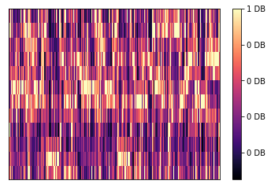

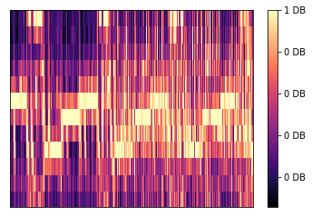

```
BEAT SYNC
(12, 50) (12, 62)
```

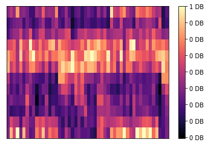

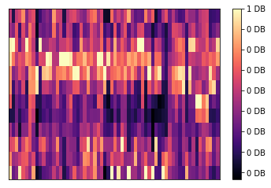

```python
print("without beat sync")
librosa.display.specshow(chroma1)
plt.colorbar(format="%d DB")
plt.show()
librosa.display.specshow(chroma2)
plt.colorbar(format="%d DB")
plt.show()


print("BEAT SYNC")
print(chroma_beat1.shape,chroma_beat2.shape)

#specshow with chroma beat
librosa.display.specshow(chroma_beat1)
plt.colorbar(format="%d DB")
plt.show()
librosa.display.specshow(chroma_beat2)
plt.colorbar(format="%d DB")
plt.show()
```

#### STEP 4

Απαντήσεις στα α) , β) του βήματος 4

**α)** Αρχικά, μας δίνεται ένα μεγάλο dictionary το class_mapping το οποίο αντιστοιχεί κάποια είδη μουσικής που είναι πολύ ειδικά πχ psych-rock και post-rock σε κάτι πιο γενικό όπως το rock στη συγκεκριμένη περίπτωση. Αυτό γίνεται, ώστε το μοντέλο μας να είναι πιο εύκολο να εκπαιδευτεί με παραπάνω δείγματα. Πέρα από αυτό όμως θα ήταν πολύ δύσκολο να διαχωρίσει 2 κατηγορίες , όμοιες μεταξύ τους όπως post rock και psych rock.

Στη συνέχεια, μας δίνονται οι συναρτήσεις read_fused_spectrogram , read_chromagram και read_mel_spectrogram οι οποίες διαβάζουν το αρχέιο στο path που τους δίνεται ως μεταβλητή και επιστρέφουν αντίστοιχα τα κατάλληλα χαρακτηριστικά, π.χ. αν είναι read chromagram θέλουμε τις 12 τελευταίες συχνότητες , αλλιώς αν είανι mel spectrogram θέλουμε τις πρώτες 128. Αν θέλουμε και τα 2 μαζί τότε φέρνει όλο το δείγμα με τις 140 συχνότητες.

Μας δίνεται μια κλάση LabelTransformer ,η οποία κληρονομεί την LabelEncoder του scikit και ουσιαστικά μας κάνει transform τα labels από string σε κατηγορικές μεταβλητές, ενώ όταν θελήσουμε μπορούμε να τα επαναφέρουμε στην αρχική δομή των labels.

Στη συνέχεια μας δίνεται η κλάση SpectrogramDataset η οποία μετατρέπει τα δεδομένα μας σε ένα dataset το οποίο είναι στη μορφή που το θέλει το pytorch για να μας διευκολύνει σε διάφορα ζητήματα όπως data loaders , batch sizes κλπ. Η συνάρτηση αυτή διαβάζει τα αρχεία από το path τα αποθηκεύει μαζί με τα labels και τα length της πραγματικής ακολουθίας τους δηλαδή πριν γίνει padded, ώστε να πάρουμε το σωστό output από το lstm μας.Έπειτα , υλοποιεί τις συναρτήσεις **getitem** και **len** οι οποίες είναι magic functions της python. H getitem θα μας επιστρέφει το δείγμα(padded), το label και το μέγεθος της πραγματικής ακολουθίας του.

Επιπρόσθετα, έχουμε τη κλάση paddingTransform η οποία κληρονομεί τη κλάση object(δεν είναι απαραίτητο στην python 3 ),ώστε να κάνει override την **call**. Όταν αυτή η κλάση δημιουργεί ένα αντικείμενο, τότε περνάμε το max length των εκάστοτε δεδομένων που περνάμε στη SpectrogramDataset. Έπειτα, κάθε φορά που θα καλέιται αυτό το αντικείμενο , με παράμετρο ένα δείγμα, θα το paddarei με 0 ανάλογα με το αν το πραγματικό του μέγεθος είναι μεγαλύτερο,μικρότερο ή ίσο με το max_length.

Τέλος, έχουμε τη συνάρτηση torch_train_val_split η οποία διαχωρίζει το dataset μας σε train και validation δεδομένα ανάλογα με το ποσοστό που θέλουμε(έχει και δυνατότητα shuffle). Επιστρέφει τα 2 data loaders , ένα για train και ένα για validation.

```python
import numpy as np
import copy
from sklearn.preprocessing import LabelEncoder
from torch.utils.data import Dataset
from torch.utils.data import SubsetRandomSampler, DataLoader
import re
```

```python
# Combine similar classes and remove underrepresented classes
class_mapping = {
    'Rock': 'Rock',
    'Psych-Rock': 'Rock',
    'Indie-Rock': None,
    'Post-Rock': 'Rock',
    'Psych-Folk': 'Folk',
    'Folk': 'Folk',
    'Metal': 'Metal',
    'Punk': 'Metal',
    'Post-Punk': None,
    'Trip-Hop': 'Trip-Hop',
    'Pop': 'Pop',
    'Electronic': 'Electronic',
    'Hip-Hop': 'Hip-Hop',
    'Classical': 'Classical',
    'Blues': 'Blues',
    'Chiptune': 'Electronic',
    'Jazz': 'Jazz',
    'Soundtrack': None,
    'International': None,
    'Old-Time': None
}
```

```python
def torch_train_val_split(dataset, batch_train, batch_eval,val_size=.2, shuffle=True, seed=None):
    # Creating data indices for training and validation splits:
    dataset_size = len(dataset)
    indices = list(range(dataset_size))
    val_split = int(np.floor(val_size * dataset_size))
    if shuffle:
        np.random.seed(seed)
        np.random.shuffle(indices)
    train_indices = indices[val_split:]
    val_indices = indices[:val_split]

    # Creating PT data samplers and loaders:
    train_sampler = SubsetRandomSampler(train_indices)
    val_sampler = SubsetRandomSampler(val_indices)

    train_loader = DataLoader(dataset,
                              batch_size=batch_train,
                              sampler=train_sampler)
    val_loader = DataLoader(dataset,
                            batch_size=batch_eval,
                            sampler=val_sampler)
    return train_loader, val_loader
```

```python
def read_fused_spectrogram(spectrogram_file):
    spectrogram = np.load(spectrogram_file)
    return spectrogram.T


def read_mel_spectrogram(spectrogram_file):
    spectrogram = np.load(spectrogram_file)[:128]
    return spectrogram.T


def read_chromagram(spectrogram_file):
    spectrogram = np.load(spectrogram_file)[128:]
    return spectrogram.T
```

```python
class LabelTransformer(LabelEncoder):
    def inverse(self, y):
        try:
            return super(LabelTransformer, self).inverse_transform(y)
        except:
            return super(LabelTransformer, self).inverse_transform([y])

    def transform(self, y):
        try:
            return super(LabelTransformer, self).transform(y)
        except:
            return super(LabelTransformer, self).transform([y])


# padding is needed because LSTM expects same length inputs
class PaddingTransform(object):
    def __init__(self, max_length, padding_value=0):
        self.max_length = max_length
        self.padding_value = padding_value
    #https://stackoverflow.com/questions/9663562/what-is-the-difference-between-init-and-call
    def __call__(self, s):
        if len(s) == self.max_length:
            return s

        if len(s) > self.max_length:
            return s[:self.max_length]

        if len(s) < self.max_length:
            #https://www.geeksforgeeks.org/copy-python-deep-copy-shallow-copy/
            s1 = copy.deepcopy(s)
            pad = np.zeros((self.max_length - s.shape[0], s.shape[1]), dtype=np.float32)
            s1 = np.vstack((s1, pad))
            return s1
```

```python
class SpectrogramDataset(Dataset):
    def __init__(self, path, class_mapping=None, train=True, max_length=-1, read_spec_fn=read_fused_spectrogram,sort=True):
        t = 'train' if train else 'test'
        p = os.path.join(path, t)
        self.index = os.path.join(path, "{}_labels.txt".format(t))
        self.files, labels = self.get_files_labels(self.index, class_mapping)
        self.feats = [read_spec_fn(os.path.join(p, f)) for f in self.files]
        self.feat_dim = self.feats[0].shape[1]
        self.lengths = [len(i) for i in self.feats]

        # not working for a reason...
        if sort:
            self.indexes = list(range(len(self.lengths)))
            self.indexes.sort(key=self.lengths.__getitem__, reverse=True)
            self.lengths = list(map(self.lengths.__getitem__, self.indexes))
            #print(self.lengths)
            self.feats = list(map(self.feats.__getitem__, self.indexes))
            #print([f.shape for f in self.feats] )
            labels = list(map(labels.__getitem__, self.indexes))

        self.max_length = max(self.lengths) if max_length <= 0 else max_length
        self.zero_pad_and_stack = PaddingTransform(self.max_length)
        self.label_transformer = LabelTransformer()
        if isinstance(labels, (list, tuple)):
            self.labels = np.array(self.label_transformer.fit_transform(labels)).astype('int64')
        #print([f.shape for f in self.feats] )

    def get_files_labels(self, txt, class_mapping):
        with open(txt, 'r') as fd:
            lines = [l.rstrip().split('\t') for l in fd.readlines()[1:]]
        files, labels = [], []
        for l in lines:
            label = l[1]
            if class_mapping:
                label = class_mapping[l[1]]
            if not label:
                continue
            # Kaggle automatically unzips the npy.gz format so this hack is needed
            _id = l[0].split('.')[0]
            npy_file = '{}.fused.full.npy'.format(_id)
            files.append(npy_file)
            labels.append(label)
        return files, labels



    def __getitem__(self, item):
        # TODO: Inspect output and comment on how the output is formatted
        l = min(self.lengths[item], self.max_length)
        return self.zero_pad_and_stack(self.feats[item]), self.labels[item], l


    def __len__(self):
        return len(self.labels)
```

γ) Σχεδιάστε δύο ιστογράμματα που θα δείχνουν πόσα δείγματα αντιστοιχούν σε κάθε κλάση, ένα πριν από τη διαδικασία του βήματος 4β και ένα μετά.

Παρακάτω είναι το histogram με το class mapping

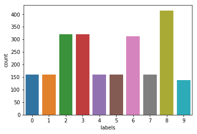

```python
import pandas as pd
import seaborn as sns
beat_chroma = SpectrogramDataset(
         '/kaggle/input/patreco3-multitask-affective-music/data/fma_genre_spectrograms_beat/',
         train=True,
         class_mapping=class_mapping,
         max_length=-1,
         read_spec_fn=read_chromagram)

lder= DataLoader(beat_chroma,batch_size=len(beat_chroma))

df = pd.DataFrame({'labels':next(iter(lder))[1]})
sns.countplot(x="labels",data=df)
```

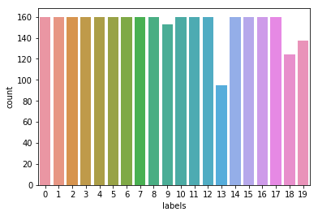

```python
import pandas as pd
import seaborn as sns
beat_chroma = SpectrogramDataset(
         '/kaggle/input/patreco3-multitask-affective-music/data/fma_genre_spectrograms_beat/',
         train=True,
         class_mapping=False,
         max_length=-1,
         read_spec_fn=read_chromagram)

lder= DataLoader(beat_chroma,batch_size=len(beat_chroma))

df = pd.DataFrame({'labels':next(iter(lder))[1]})
sns.countplot(x="labels",data=df)
```

#### STEP 5 - 6 (ΕΚΠΑΙΔΕΥΣΗ ΜΟΝΤΕΛΟΥ ΚΑΙ ΑΞΙΟΛΟΓΗΣΗ)

##### ΑΠΑΝΤΗΣΗ ΣΤΑ ΕΡΩΤΗΜΑΤΑ ΤΟΥ ΒΗΜΑΤΟΣ 6:

**1) ACCURACY: Αριθμός σωστών προβλέψεων / Συνολικός αριθμός προβλέψεων**

PRECISION: Υποδηλώνεται ως το μέτρο των σωστά προσδιορισμένων θετικών περιπτώσεων από όλες τις προβλεπόμενες θετικές περιπτώσεις. Έτσι, είναι χρήσιμο όταν το κόστος των False Positives είναι υψηλό.

RECALL: Είναι το μέτρο των σωστά προσδιορισμένων θετικών περιπτώσεων από όλες τις πραγματικές θετικές περιπτώσεις. Είναι σημαντικό όταν το κόστος των False Negatives είναι υψηλό.

F1-SCORE: Σταθμισμένο μέσο όρο του precision και recall, όπου η βαθμολογία F1 φτάνει την καλύτερη τιμή της στο 1 και το χειρότερο στο 0

Το accuracy χρησιμοποιείται όταν τα True Positive και τα True Negative είναι πιο σημαντικά ενώ F1 -score χρησιμοποιείται όταν τα False Negatives και False Positives είναι πιο σημαντικά. Το accuracy μπορεί να χρησιμοποιηθεί όταν η κατανομή της τάξης είναι παρόμοια, ενώ η βαθμολογία F1 είναι καλύτερη μετρική όταν υπάρχουν imbalanced classes.

Στα περισσότερα προβλήματα ταξινόμησης της πραγματικής ζωής, η ισορροπημένη κατανομή τάξης δεν υπάρχει και έτσι η βαθμολογία F1 είναι μια καλύτερη μετρική για την αξιολόγηση του μοντέλου μας.

**2) Τι δείχνει το micro / macro averaged precision / recall / f1 score;**

macro-averaged F1-score, or the macro-F1 υπολογίζεται ως απλός αριθμητικός μέσος των βαθμών F1 ανά κατηγορία.

Ομοίως και τα macro-averaged recall και macro-averaged precision είναι ο αριθμτικός μέσων των τιμών τους για κάθε κλάση.

Προσοχή καθώς, στο averaged δε δώσαμε κάποιο βάρος σε κάθε class, αν θέλαμε το macro/micro weighted , τότε πολλαπλασιάζουμε την τιμή της μετρικής για κάθε class με τον αριθμό δειγμάτων που έχει.

Τέλος θα πούμε για το micro-averaged [f1,precision,recall,accuracy].

Tο micro-average θα προσθέσει τα contributions(ποσοστό δειγμάτων που ανήκουν στη κλάση) κάθε κλάσης ώστε να βρει το μέσο όρο της μετρικής που χρησιμοποιήθηκε.Σε αντίθεση με το macro-averaged που υπολογίζει τη μετρική για κάθε τάξη και μετά παίρνει το μέσο όρο.

Στην περίπτωση του micro, που είναι ίσα το precision με το recall επομένως και το f1 score είναι ίσο με τις άλλες 2 μετρικές. Επομένως, ισχύει:

```
            micro-f1 = micro-precision=micro-recall=accuracy
```

**3) Πότε μπορεί να έχω μεγάλη απόκλιση ανάμεσα στο accuracy / f1 score και τι σημαίνει αυτό;** Αυτό μπορεί να επιτευχθεί, αν έχω μη ισορροπημένες κλάσεις ως προς τον αριθμό των δεδομένων.

**4)Πότε μπορεί να έχω μεγάλη απόκλιση ανάμεσα στο micro/macro f1 score και τι σημαίνει αυτό;** Μεγάλη απόκλιση σε αυτά τα 2 έχω όταν τα δεδομένα μας αποτελούνται από imbalanced classes. Αν τα δείγματα μεταξύ των κλάσεων απέχουν πολύ, τότε αυτές οι 2 τιμές θα έχουν μεγάλη απόκλιση.

Αυτό συμβαίνει γιατί το macro δίνει ισότιμα βάρη στις κλάσεις , ενώ τα micro δίνουν ισότιμα βάρη σε κάθε δείγμα ξεχωριστά. Αν η κατανομή των τάξεων είναι συμμετρική , τότε αυτές οι 2 τιμές θα έχουν ίδιο σκορ.

**5) Υπάρχουν προβλήματα όπου το precision με ενδιαφέρει περισσότερο από το recall και αντίστροφα; Είναι ένα καλό accuracy / f1 αρκετό σε αυτές τις περιπτώσεις για να επιλέξω ένα μοντέλο;**

Για youtube recommendations, τα FALSE-NEGATIVE δε μας ενδιαφέρουν ιδιαίτερα, οπότε το Precision θα ήταν καλύτερη μετρική απόο το recall.

Όμως σε ένα πρόβλημα πρόγνωσης αν κάποιος πάσχει από καρκίνο , το FALSE-NEGATIVE είναι πολύ σημαντικό, καθώς το να δείξεις πως κάποιος δε πάσχει από καρκίνο, ενώ πάσχει, είναι εγκληματικό.

Για αυτές τις 2 περιπτώσεις το accuracy δε θα ήταν καλή μετρική για τον καρκίνο, καθώς θέλουμε να εστιάσουμε στην ελάττωση του FALSE-NEGATIVE. Στην περίπτωση με το youtube όμως θα μπορούσε.

1.ΠΑΡΑΚΑΤΩ ΕΙΝΑΙ Ο ΚΩΔΙΚΑΣ ΓΙΑ ΤΟ ΜΟΝΤΕΛΟ ΜΑΣ , Η ΣΥΝΑΡΤΗΣΗ ΕΚΠΑΙΔΕΥΣΗΣ , ΤΟ EARLYSTOPPING ΚΑΙ ΤΟ TEST EVAL **

```python
import sys
```

LSTM CODE

```python
import torch.nn as nn
class BasicLSTM(nn.Module):
    def __init__(self, input_dim, rnn_size, output_dim, num_layers, dropout, bidirectional=False, pad_packed=False):
        super(BasicLSTM, self).__init__()
        self.bidirectional = bidirectional
        self.feature_size = rnn_size * 2 if self.bidirectional else rnn_size
        # --------------- Insert your code here ---------------- #
        # Initialize the LSTM, Dropout, Output layers
        self.input_size = input_dim
        self.num_layers= num_layers
        self.output_size = output_dim
        self.dropout = dropout
        self.pad_packed = pad_packed
        self.lstm = nn.LSTM(self.input_size, rnn_size, self.num_layers, dropout=self.dropout,
                            batch_first=True, bidirectional=self.bidirectional)
        self.fc = nn.Linear(self.feature_size, self.output_size)

    def forward(self, x, lengths):
        """
            x : 3D numpy array of dimension N x L x D
                N: batch index
                L: sequence index
                D: feature index

            lengths: N x 1
         """

        # --------------- Insert your code here ---------------- #

        # You must have all of the outputs of the LSTM, but you need only the last one (that does not exceed the sequence length)
        # To get it use the last_timestep method
        # Then pass it through the remaining network
        # if stacked is true use pack_padded_sequence and pad_packed_sequence
        if self.pad_packed:
            packed = nn.utils.rnn.pack_padded_sequence(x, lengths, batch_first=True)
            lstm_outs, hidden = self.lstm(packed)
            lstm_outs, lengths = nn.utils.rnn.pad_packed_sequence(lstm_outs, batch_first=True)
        else:
            lstm_outs, hidden = self.lstm(x)
        last_out = self.last_timestep(lstm_outs, lengths, self.bidirectional)
        output = self.fc(last_out)
        return output

    def last_timestep(self, outputs, lengths, bidirectional=False):
        """
            Returns the last output of the LSTM taking into account the zero padding
        """
        if bidirectional:
            forward, backward = self.split_directions(outputs)
            last_forward = self.last_by_index(forward, lengths)
            last_backward = backward[:, 0, :]
            # Concatenate and return - maybe add more functionalities like average
            return torch.cat((last_forward, last_backward), dim=-1)
        else:
            return self.last_by_index(outputs, lengths)

    @staticmethod
    def split_directions(outputs):
        direction_size = int(outputs.size(-1) / 2)
        forward = outputs[:, :, :direction_size]
        backward = outputs[:, :, direction_size:]
        return forward, backward

    @staticmethod
    def last_by_index(outputs, lengths):
        # Index of the last output for each sequence.
        idx = (lengths - 1).view(-1, 1).expand(outputs.size(0),
                                               outputs.size(2)).unsqueeze(1)
        return outputs.gather(1, idx).squeeze()
```

```python
#change my model parameters to double , so it can get double tensors
model = BasicLSTM(input_dim=140, rnn_size=128, output_dim=10, num_layers=4, dropout=0.2, bidirectional=True, pad_packed=False).double()
#model.train() its by default on train mode
criterion =  nn.CrossEntropyLoss()
optimizer = torch.optim.Adam(model.parameters(), weight_decay=0.001)
```

```python
import numpy as np
import torch
class EarlyStopping:
    def __init__(self, patience=7, verbose=False):
        self.patience = patience
        self.verbose = verbose
        self.counter = 0
        self.best_score = None
        self.early_stop = False
        self.val_loss_min = np.Inf

    def __call__(self, val_loss, model):

        score = -val_loss

        if self.best_score is None:
            self.best_score = score
            self.save_checkpoint(val_loss, model)
        elif score < self.best_score:
            self.counter += 1
            print(f'EarlyStopping counter: {self.counter} out of {self.patience}')
            if self.counter >= self.patience:
                self.early_stop = True
        else:
            self.best_score = score
            self.save_checkpoint(val_loss, model)
            self.counter = 0

    def save_checkpoint(self, val_loss, model):
        '''Saves model when validation loss decrease.'''
        if self.verbose:
            print(f'Validation loss decreased ({self.val_loss_min:.6f} --> {val_loss:.6f}).  Saving model ...')
        torch.save(model.state_dict(), 'checkpoint.pt')
        self.val_loss_min = val_loss
```

```python
def train(model,dataloaders,num_epochs,optimizer,patience):
    Flag=False
    # for loss
    val_loss = []
    train_loss = []
    phase1 = dataloaders.keys()
    criterion = nn.CrossEntropyLoss()
    train_loader = dataloaders['train']
    if(torch.cuda.is_available()):
        device = 0
        model.to(device)
    else:
        device = 1
        model.to(device)
    if(patience!=None):
        earlystop = EarlyStopping(patience = patience,verbose = True)
    for epoch in range(num_epochs):
        counter = epoch # keeping this variable for plot function after for loop
        if Flag == True:
            break
        print('Epoch:',epoch + 1)
        epoch_metrics = {"loss": [], "acc": []}
        for phase in phase1:
            if phase == 'train':
                model.train()
            else:
                model.eval()
            for  batch_idx, data in enumerate(dataloaders[phase]):
                optimizer.zero_grad()
                output = model(data[0].to(device), data[2].to(device))
                loss = criterion(output, data[1].to(device))
                acc = 100 * (output.detach().argmax(1) == data[1].to(device)).cpu().numpy().mean()
                epoch_metrics["loss"].append(loss.item())
                epoch_metrics["acc"].append(acc)
                sys.stdout.write(
                "\r[Epoch %d/%d] [Batch %d/%d] [Loss: %f (%f), Acc: %.2f%% (%.2f%%)]"
                % (
                    epoch + 1,
                    num_epochs,
                    batch_idx,
                    len(dataloaders[phase]),
                    loss.item(),
                    np.mean(epoch_metrics["loss"]),
                    acc,
                    np.mean(epoch_metrics["acc"]),
                    )
                )

                if(phase =='train'):
                    loss.backward()
                    optimizer.step()

            epoch_acc = np.mean(epoch_metrics["acc"])
            epoch_loss = np.mean(epoch_metrics["loss"])

            if phase == 'train':
                train_loss.append(epoch_loss)
            else:
                val_loss.append(epoch_loss)
            if(phase == 'val' and patience !=None):
                earlystop(epoch_loss,model)
                if(earlystop.early_stop):
                    print("Early stopping")
                    model.load_state_dict(torch.load('./checkpoint.pt'))
                    print('{} Accuracy: {}'.format(phase,epoch_acc.item()))
                    #break
                    Flag = True
        print('{} Accuracy: {}'.format(phase,epoch_acc.item()))
    if counter == num_epochs -1:
        epochs_axis = np.arange(num_epochs)
    else:
        epochs_axis = np.arange(counter)
    plt.plot(epochs_axis, train_loss,color='red')
    plt.plot(epochs_axis, val_loss,color='blue')
    plt.legend(['training-red', 'validation-blue'], loc='upper left')
    plt.show()
```

```python
def predictLSTM(test_loader, model, criterion):
    predictions, y_test, test_loss = [], [], []
    #model.load_state_dict(torch.load("LSTMmodel_params.pt"))
    # set eval mode in order to stop dropout during inference
    model.eval()
    model.to(0)
    for i_batch, data_batched in enumerate(test_loader, 0):
        data_batched[0], data_batched[2] = data_batched[0].to(0), data_batched[2].to(0)
        y_pred = model(data_batched[0], data_batched[2]).to(0)
        preds = y_pred.data.cpu().numpy()
        predictions += list(np.argmax(preds, axis=1))
        # get sorted version of y_test
        data_batched[1] = data_batched[1].to(0)
        y_test += list(data_batched[1].data.cpu().numpy())
        loss = criterion(y_pred, data_batched[1])
        test_loss.append(loss.item())
    total_loss = np.mean(test_loss)
    print('Test loss: {}'.format(total_loss))
    accuracy = np.sum(np.asarray(predictions) == np.asarray(y_test)) / len(y_test)
    print("Test set accuracy is {:.2f}% ".format(accuracy*100))
    return(predictions, y_test)
```

```python
sort = False
#train val set
mel_specs = SpectrogramDataset(
         '/kaggle/input/patreco3-multitask-affective-music/data/fma_genre_spectrograms/',
         train=True,
         class_mapping=class_mapping,
         max_length=-1,
         read_spec_fn=read_fused_spectrogram)

train_loader_mel, val_loader_mel = torch_train_val_split(mel_specs, 32 ,32, val_size=.1)

#test
test_loader_mel = SpectrogramDataset(
          '/kaggle/input/patreco3-multitask-affective-music/data/fma_genre_spectrograms/',
         train=False,
         class_mapping=class_mapping,
         max_length=-1,
         read_spec_fn=read_fused_spectrogram)

dataloaders = {'train':train_loader_mel,'val':val_loader_mel}
```

```
Epoch: 1
[Epoch 1/20] [Batch 7/8] [Loss: 2.282084 (2.227401), Acc: 16.67% (17.63%)]Validation loss decreased (inf --> 2.227401).  Saving model ...
val Accuracy: 17.6322298325723
Epoch: 2
[Epoch 2/20] [Batch 7/8] [Loss: 2.402431 (2.200254), Acc: 0.00% (19.58%)]Validation loss decreased (2.227401 --> 2.200254).  Saving model ...
val Accuracy: 19.58396752917301
Epoch: 3
[Epoch 3/20] [Batch 7/8] [Loss: 2.149362 (2.187380), Acc: 16.67% (20.04%)]Validation loss decreased (2.200254 --> 2.187380).  Saving model ...
val Accuracy: 20.03741755454084
Epoch: 4
[Epoch 4/20] [Batch 7/8] [Loss: 2.203208 (2.158846), Acc: 16.67% (21.19%)]Validation loss decreased (2.187380 --> 2.158846).  Saving model ...
val Accuracy: 21.18531202435312
Epoch: 5
[Epoch 5/20] [Batch 7/8] [Loss: 2.122230 (2.172483), Acc: 33.33% (20.79%)]EarlyStopping counter: 1 out of 3
val Accuracy: 20.787354134956875
Epoch: 6
[Epoch 6/20] [Batch 7/8] [Loss: 2.045234 (2.130110), Acc: 33.33% (22.24%)]Validation loss decreased (2.158846 --> 2.130110).  Saving model ...
val Accuracy: 22.242833587011667
Epoch: 7
[Epoch 7/20] [Batch 7/8] [Loss: 2.442089 (2.120315), Acc: 0.00% (22.67%)]Validation loss decreased (2.130110 --> 2.120315).  Saving model ...
val Accuracy: 22.6693302891933
Epoch: 8
[Epoch 8/20] [Batch 7/8] [Loss: 1.490721 (2.098050), Acc: 50.00% (22.79%)]Validation loss decreased (2.120315 --> 2.098050).  Saving model ...
val Accuracy: 22.78665651953323
Epoch: 9
[Epoch 9/20] [Batch 7/8] [Loss: 1.978949 (2.109391), Acc: 16.67% (22.45%)]EarlyStopping counter: 1 out of 3
val Accuracy: 22.450532724505326
Epoch: 10
[Epoch 10/20] [Batch 7/8] [Loss: 2.430646 (2.103715), Acc: 0.00% (22.86%)]EarlyStopping counter: 2 out of 3
val Accuracy: 22.856418061897514
Epoch: 11
[Epoch 11/20] [Batch 7/8] [Loss: 2.359641 (2.113121), Acc: 0.00% (22.87%)]EarlyStopping counter: 3 out of 3
Early stopping
val Accuracy: 22.872272957889397
val Accuracy: 22.872272957889397
```

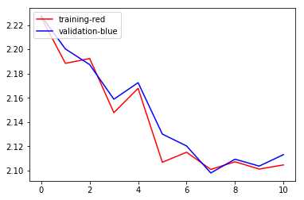

```python
optim = torch.optim.Adam(model.parameters(),lr = 0.001,weight_decay = 1e-3) # weight decay is for l2 regularization
train(model,dataloaders,20,optim,3) # 3 patience
```

```python
test_loader = DataLoader(test_loader_mel,batch_size=32)
#model.eval()
ypred, ytrue = predictLSTM(test_loader, model, criterion)
from sklearn.metrics import classification_report
print(classification_report(ytrue, ypred))
```

```
Test loss: 2.1060521962829544
Test set accuracy is 23.30%
              precision    recall  f1-score   support

           0       0.00      0.00      0.00        40
           1       0.00      0.00      0.00        40
           2       0.24      0.57      0.34        80
           3       0.14      0.04      0.06        80
           4       0.00      0.00      0.00        40
           5       0.00      0.00      0.00        40
           6       0.00      0.00      0.00        78
           7       0.00      0.00      0.00        40
           8       0.23      0.83      0.36       103
           9       0.00      0.00      0.00        34

    accuracy                           0.23       575
   macro avg       0.06      0.14      0.08       575
weighted avg       0.10      0.23      0.12       575
```

**5B) ΕΚΠΑΙΔΕΥΣΗ ΚΑΙ ΑΠΟΤΕΛΕΣΜΑΤΑ ΜΕ ΧΡΗΣΗ ΔΕΔΟΜΕΝΩΝ BEATSYNC ~ MEL SPECTROGRAM**

```python
sort = False
#train val set
mel_specs = SpectrogramDataset(
         '/kaggle/input/patreco3-multitask-affective-music/data/fma_genre_spectrograms_beat/',
         train=True,
         class_mapping=class_mapping,
         max_length=-1,
         read_spec_fn=read_mel_spectrogram)

train_loader_mel, val_loader_mel = torch_train_val_split(mel_specs, 32 ,32, val_size=.1)

#test
test_loader_mel = SpectrogramDataset(
          '/kaggle/input/patreco3-multitask-affective-music/data/fma_genre_spectrograms_beat/',
         train=False,
         class_mapping=class_mapping,
         max_length=-1,
         read_spec_fn=read_mel_spectrogram)

dataloaders = {'train':train_loader_mel,'val':val_loader_mel}
```

```python
test_loader = DataLoader(test_loader_mel,batch_size=32)
#model.eval()
```

```
Epoch: 1
[Epoch 1/20] [Batch 7/8] [Loss: 2.023525 (2.223370), Acc: 33.33% (16.66%)]Validation loss decreased (inf --> 2.223370).  Saving model ...
val Accuracy: 16.6619101978691
Epoch: 2
[Epoch 2/20] [Batch 7/8] [Loss: 1.920758 (2.139114), Acc: 33.33% (20.73%)]Validation loss decreased (2.223370 --> 2.139114).  Saving model ...
val Accuracy: 20.728691019786908
Epoch: 3
[Epoch 3/20] [Batch 7/8] [Loss: 2.033158 (2.054224), Acc: 16.67% (24.82%)]Validation loss decreased (2.139114 --> 2.054224).  Saving model ...
val Accuracy: 24.824010654490106
Epoch: 4
[Epoch 4/20] [Batch 7/8] [Loss: 1.832731 (1.996534), Acc: 33.33% (28.83%)]Validation loss decreased (2.054224 --> 1.996534).  Saving model ...
val Accuracy: 28.832128361237952
Epoch: 5
[Epoch 5/20] [Batch 7/8] [Loss: 1.654866 (1.996435), Acc: 50.00% (28.34%)]Validation loss decreased (1.996534 --> 1.996435).  Saving model ...
val Accuracy: 28.343797564687975
Epoch: 6
[Epoch 6/20] [Batch 7/8] [Loss: 1.947509 (1.955942), Acc: 33.33% (29.50%)]Validation loss decreased (1.996435 --> 1.955942).  Saving model ...
val Accuracy: 29.501204972095383
Epoch: 7
[Epoch 7/20] [Batch 7/8] [Loss: 1.346332 (1.962403), Acc: 83.33% (29.61%)]EarlyStopping counter: 1 out of 3
val Accuracy: 29.613774733637747
Epoch: 8
[Epoch 8/20] [Batch 7/8] [Loss: 2.056602 (1.953604), Acc: 16.67% (29.06%)]Validation loss decreased (1.955942 --> 1.953604).  Saving model ...
val Accuracy: 29.058853373921863
Epoch: 9
[Epoch 9/20] [Batch 7/8] [Loss: 2.255333 (1.976354), Acc: 16.67% (29.04%)]EarlyStopping counter: 1 out of 3
val Accuracy: 29.039827498731608
Epoch: 10
[Epoch 10/20] [Batch 7/8] [Loss: 2.175888 (1.928589), Acc: 33.33% (31.75%)]Validation loss decreased (1.953604 --> 1.928589).  Saving model ...
val Accuracy: 31.75418569254186
Epoch: 11
[Epoch 11/20] [Batch 7/8] [Loss: 2.200159 (1.952755), Acc: 16.67% (29.12%)]EarlyStopping counter: 1 out of 3
val Accuracy: 29.120687468290203
Epoch: 12
[Epoch 12/20] [Batch 7/8] [Loss: 2.166402 (1.932323), Acc: 0.00% (30.41%)]EarlyStopping counter: 2 out of 3
val Accuracy: 30.406519533231865
Epoch: 13
[Epoch 13/20] [Batch 7/8] [Loss: 2.357534 (1.903397), Acc: 0.00% (32.20%)]Validation loss decreased (1.928589 --> 1.903397).  Saving model ...
val Accuracy: 32.204464738711316
Epoch: 14
[Epoch 14/20] [Batch 7/8] [Loss: 1.720426 (1.921441), Acc: 50.00% (30.62%)]EarlyStopping counter: 1 out of 3
val Accuracy: 30.620560629122274
Epoch: 15
[Epoch 15/20] [Batch 7/8] [Loss: 1.413422 (1.906954), Acc: 66.67% (32.18%)]EarlyStopping counter: 2 out of 3
val Accuracy: 32.175925925925924
Epoch: 16
[Epoch 16/20] [Batch 7/8] [Loss: 2.284538 (1.906573), Acc: 0.00% (30.65%)]EarlyStopping counter: 3 out of 3
Early stopping
val Accuracy: 30.64751395230847
val Accuracy: 30.64751395230847
```

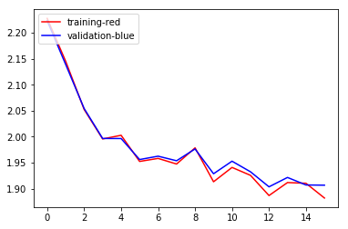

```python
model2 = BasicLSTM(input_dim=128, rnn_size=128, output_dim=10, num_layers=4, dropout=0.2, bidirectional=True, pad_packed=False).double()
optim2 = torch.optim.Adam(model2.parameters(),lr = 0.001,weight_decay = 1e-3) # weight decay is for l2 regularization
train(model2,dataloaders,20,optim2,3) # 3 patience
```

```python
ypred, ytrue = predictLSTM(test_loader, model2, criterion)
print(classification_report(ytrue, ypred))
#https://stackoverflow.com/questions/43162506/undefinedmetricwarning-f-score-is-ill-defined-and-being-set-to-0-0-in-labels-wi
```

```
Test loss: 1.9597736823756842
Test set accuracy is 28.87%
              precision    recall  f1-score   support

           0       0.00      0.00      0.00        40
           1       0.28      0.65      0.39        40
           2       0.30      0.54      0.38        80
           3       0.26      0.66      0.38        80
           4       0.00      0.00      0.00        40
           5       0.00      0.00      0.00        40
           6       0.00      0.00      0.00        78
           7       0.00      0.00      0.00        40
           8       0.33      0.43      0.37       103
           9       0.00      0.00      0.00        34

    accuracy                           0.29       575
   macro avg       0.12      0.23      0.15       575
weighted avg       0.16      0.29      0.20       575
```

```python
#print(torch.cuda.is_available())
'''
#Saving a checkpoint
torch.save(checkpoint, 'checkpoint.pth')
#Loading a checkpoint
checkpoint = torch.load( 'checkpoint.pth')
'''
'''
checkpoint = {'model': BasicLSTM(input_dim=128, rnn_size=128, output_dim=10, num_layers=4, dropout=0.2, bidirectional=True, pad_packed=False).double(),
          'state_dict': model.state_dict(),
          'optimizer' : optimizer.state_dict()}

torch.save(checkpoint, 'checkpoint.pth')
'''
```

```python
def load_checkpoint(filepath):
    checkpoint = torch.load(filepath)
    model = checkpoint['model']
    model.load_state_dict(checkpoint['state_dict'])
    for parameter in model.parameters():
        parameter.requires_grad = False

    model.eval()
    return model

#model_load = load_checkpoint('checkpoint.pth')
```

```python
#model_load.state_dict
```

**5C) εκπαιδεύστε ένα LSTM δίκτυο, το οποίο θα δέχεται ως είσοδο τα χρωμογραφήματα (train set) και θα προβλέπει τις διαφορετικές κλάσεις (μουσικά είδη) του dataset.**

```python
sort = False
#train val set
chroma_specs = SpectrogramDataset(
         '/kaggle/input/patreco3-multitask-affective-music/data/fma_genre_spectrograms_beat/',
         train=True,
         class_mapping=class_mapping,
         max_length=-1,
         read_spec_fn=read_chromagram)

train_loader_chroma, val_loader_chroma = torch_train_val_split(chroma_specs, 32 ,32, val_size=.1)

#test
test_loader_chroma = SpectrogramDataset(
          '/kaggle/input/patreco3-multitask-affective-music/data/fma_genre_spectrograms_beat/',
         train=False,
         class_mapping=class_mapping,
         max_length=-1,
         read_spec_fn=read_chromagram)

dataloaders = {'train':train_loader_chroma,'val':val_loader_chroma}
```

```
Epoch: 1
[Epoch 1/20] [Batch 7/8] [Loss: 2.366509 (2.238970), Acc: 0.00% (17.03%)]Validation loss decreased (inf --> 2.238970).  Saving model ...
val Accuracy: 17.034500253678335
Epoch: 2
[Epoch 2/20] [Batch 7/8] [Loss: 2.346390 (2.231872), Acc: 33.33% (18.18%)]Validation loss decreased (2.238970 --> 2.231872).  Saving model ...
val Accuracy: 18.1839802130898
Epoch: 3
[Epoch 3/20] [Batch 7/8] [Loss: 2.547469 (2.229967), Acc: 0.00% (17.82%)]Validation loss decreased (2.231872 --> 2.229967).  Saving model ...
val Accuracy: 17.820903094875696
Epoch: 4
[Epoch 4/20] [Batch 7/8] [Loss: 2.089447 (2.225992), Acc: 33.33% (18.17%)]Validation loss decreased (2.229967 --> 2.225992).  Saving model ...
val Accuracy: 18.168125317097918
Epoch: 5
[Epoch 5/20] [Batch 7/8] [Loss: 2.216655 (2.225052), Acc: 0.00% (17.84%)]Validation loss decreased (2.225992 --> 2.225052).  Saving model ...
val Accuracy: 17.84468543886352
Epoch: 6
[Epoch 6/20] [Batch 7/8] [Loss: 2.353479 (2.227677), Acc: 0.00% (17.78%)]EarlyStopping counter: 1 out of 3
val Accuracy: 17.78126585489599
Epoch: 7
[Epoch 7/20] [Batch 7/8] [Loss: 2.572916 (2.228848), Acc: 0.00% (17.81%)]EarlyStopping counter: 2 out of 3
val Accuracy: 17.805048198883814
Epoch: 8
[Epoch 8/20] [Batch 7/8] [Loss: 2.164979 (2.225181), Acc: 16.67% (18.00%)]EarlyStopping counter: 3 out of 3
Early stopping
val Accuracy: 17.99847792998478
val Accuracy: 17.99847792998478
```

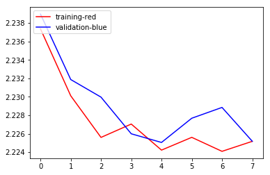

```python
#import sys
model3 = BasicLSTM(input_dim=12, rnn_size=128, output_dim=10, num_layers=4, dropout=0.2, bidirectional=True, pad_packed=False).double()
optim3 = torch.optim.Adam(model3.parameters(),lr = 0.001,weight_decay = 1e-3) # weight decay is for l2 regularization
train(model3,dataloaders,20,optim3,3) # 3 patience
```

```python
test_loader = DataLoader(test_loader_chroma ,batch_size=32)

ypred, ytrue = predictLSTM(test_loader, model3, criterion)

print(classification_report(ytrue, ypred))
```

```
Test loss: 2.224641115028552
Test set accuracy is 17.91%
              precision    recall  f1-score   support

           0       0.00      0.00      0.00        40
           1       0.00      0.00      0.00        40
           2       0.00      0.00      0.00        80
           3       0.00      0.00      0.00        80
           4       0.00      0.00      0.00        40
           5       0.00      0.00      0.00        40
           6       0.00      0.00      0.00        78
           7       0.00      0.00      0.00        40
           8       0.18      1.00      0.30       103
           9       0.00      0.00      0.00        34

    accuracy                           0.18       575
   macro avg       0.02      0.10      0.03       575
weighted avg       0.03      0.18      0.05       575
```

**δ) (extra credit) εκπαιδεύστε ένα LSTM δίκτυο, το οποίο θα δέχεται ως είσοδο τα ενωμένα (concatenated) χρωμογραφήματα και φασματογραφήματα (train set) και θα προβλέπει τις διαφορετικές κλάσεις (μουσικά είδη) του dataset.**

```python
sort = False
#train val set
fused_specs = SpectrogramDataset(
         '/kaggle/input/patreco3-multitask-affective-music/data/fma_genre_spectrograms_beat/',
         train=True,
         class_mapping=class_mapping,
         max_length=-1,
         read_spec_fn=read_fused_spectrogram)

train_loader_fused, val_loader_fused = torch_train_val_split(fused_specs, 32 ,32, val_size=.1)

#test
test_loader_fused = SpectrogramDataset(
          '/kaggle/input/patreco3-multitask-affective-music/data/fma_genre_spectrograms_beat/',
         train=False,
         class_mapping=class_mapping,
         max_length=-1,
         read_spec_fn=read_fused_spectrogram)

dataloaders = {'train':train_loader_fused,'val':val_loader_fused}
```

```python
model4 = BasicLSTM(input_dim=140, rnn_size=256, output_dim=10, num_layers=4, dropout=0.2, bidirectional=True, pad_packed=False).double()
optim4 = torch.optim.Adam(model4.parameters(),lr = 0.001,weight_decay = 1e-3) # weight decay is for l2 regularization
train(model4,dataloaders,20,optim4,8) # 8 patience
```

[output not shown]

```python
test_loader = DataLoader(test_loader_fused ,batch_size=32)

ypred, ytrue = predictLSTM(test_loader, model4, criterion)

print(classification_report(ytrue, ypred))
```

```
Test loss: 2.3051037753292096
Test set accuracy is 6.96%
              precision    recall  f1-score   support

           0       0.00      0.00      0.00        40
           1       0.00      0.00      0.00        40
           2       0.00      0.00      0.00        80
           3       0.00      0.00      0.00        80
           4       0.07      1.00      0.13        40
           5       0.00      0.00      0.00        40
           6       0.00      0.00      0.00        78
           7       0.00      0.00      0.00        40
           8       0.00      0.00      0.00       103
           9       0.00      0.00      0.00        34

    accuracy                           0.07       575
   macro avg       0.01      0.10      0.01       575
weighted avg       0.00      0.07      0.01       575
```

ΤΕΛΟΣ ΠΡΟΠΑΡΑΣΚΕΥΑΣΤΙΚΗΣ ΕΡΓΑΣΙΑΣ